# Proyecto 1 - Aprendizaje Automático De Máquina I

## Integrantes

- González Rodríguez Laura Valentina
- Mora Romero Diryon Yonith

```python
# Importar paquetes
%matplotlib inline
import pandas as pd
import numpy as np
import matplotlib.pyplot as plt
from sklearn.model_selection import train_test_split, cross_val_score
from sklearn.linear_model import Ridge, RidgeCV, Lasso, LassoCV
from sklearn.metrics import mean_squared_error
from sklearn.linear_model import LinearRegression
from sklearn.tree import DecisionTreeClassifier, plot_tree, DecisionTreeRegressor
from sklearn.neighbors import KNeighborsClassifier, KNeighborsRegressor
```

## Primer Punto

*Cargar el dataset HousingData, el cual se proveer ́a junto con un diccionario de los atributos. La variable objetivo es MEDV.*

```python
df = pd.read_csv("HousingData1")
```

# Segundo Punto

*Examinar y realizar una breve descripción de los tipos de variable o cualquier observación que considere pertinente. Remueva filas con valores ausentes si en algún punto lo considera necesario.*

```python
# Nótese que hay una columna sin nombre. Además, no tiene importancia; es un ID incrementable.
df = df.drop(columns=[df.columns[0]])
# Filtrado de filas vacías
df = df.dropna()
# Información del conjunto
df.head()
```

|  | CRIM | ZN | INDUS | CHAS | NOX | RM | AGE | DIS | RAD | TAX | PTRATIO | LSTAT | MEDV |
| --- | --- | --- | --- | --- | --- | --- | --- | --- | --- | --- | --- | --- | --- |
| 0 | 0.00632 | 18.0 | 2.31 | 0.0 | 0.538 | 6.575 | 65.2 | 4.0900 | 1 | 296 | 15.3 | 4.98 | 24.0 |
| 1 | 0.02731 | 0.0 | 7.07 | 0.0 | 0.469 | 6.421 | 78.9 | 4.9671 | 2 | 242 | 17.8 | 9.14 | 21.6 |
| 2 | 0.02729 | 0.0 | 7.07 | 0.0 | 0.469 | 7.185 | 61.1 | 4.9671 | 2 | 242 | 17.8 | 4.03 | 34.7 |
| 3 | 0.03237 | 0.0 | 2.18 | 0.0 | 0.458 | 6.998 | 45.8 | 6.0622 | 3 | 222 | 18.7 | 2.94 | 33.4 |
| 5 | 0.02985 | 0.0 | 2.18 | 0.0 | 0.458 | 6.430 | 58.7 | 6.0622 | 3 | 222 | 18.7 | 5.21 | 28.7 |

```python
# Resumen de la información en base a las columnas
df.info()
```

```
<class 'pandas.core.frame.DataFrame'>
Int64Index: 394 entries, 0 to 504
Data columns (total 13 columns):
 #   Column   Non-Null Count  Dtype
---  ------   --------------  -----
 0   CRIM     394 non-null    float64
 1   ZN       394 non-null    float64
 2   INDUS    394 non-null    float64
 3   CHAS     394 non-null    float64
 4   NOX      394 non-null    float64
 5   RM       394 non-null    float64
 6   AGE      394 non-null    float64
 7   DIS      394 non-null    float64
 8   RAD      394 non-null    int64
 9   TAX      394 non-null    int64
 10  PTRATIO  394 non-null    float64
 11  LSTAT    394 non-null    float64
 12  MEDV     394 non-null    float64
dtypes: float64(11), int64(2)
memory usage: 43.1 KB
```

```python
# Descripción estadistica de los datos, mostrando las medidas de tendencia central, dispersión y forma.
df.describe()
```

|  | CRIM | ZN | INDUS | CHAS | NOX | RM | AGE | DIS | RAD | TAX | PTRATIO | LSTAT | MEDV |
| --- | --- | --- | --- | --- | --- | --- | --- | --- | --- | --- | --- | --- | --- |
| count | 394.000000 | 394.000000 | 394.000000 | 394.000000 | 394.000000 | 394.000000 | 394.000000 | 394.000000 | 394.000000 | 394.000000 | 394.000000 | 394.000000 | 394.000000 |
| mean | 3.690136 | 11.460660 | 11.000863 | 0.068528 | 0.553215 | 6.280015 | 68.932741 | 3.805268 | 9.403553 | 406.431472 | 18.537563 | 12.769112 | 22.359645 |
| std | 9.202423 | 23.954082 | 6.908364 | 0.252971 | 0.113112 | 0.697985 | 27.888705 | 2.098571 | 8.633451 | 168.312419 | 2.166460 | 7.308430 | 9.142979 |
| min | 0.006320 | 0.000000 | 0.460000 | 0.000000 | 0.389000 | 3.561000 | 2.900000 | 1.129600 | 1.000000 | 187.000000 | 12.600000 | 1.730000 | 5.000000 |
| 25% | 0.081955 | 0.000000 | 5.130000 | 0.000000 | 0.453000 | 5.879250 | 45.475000 | 2.110100 | 4.000000 | 280.250000 | 17.400000 | 7.125000 | 16.800000 |
| 50% | 0.268880 | 0.000000 | 8.560000 | 0.000000 | 0.538000 | 6.201500 | 77.700000 | 3.199200 | 5.000000 | 330.000000 | 19.100000 | 11.300000 | 21.050000 |
| 75% | 3.435973 | 12.500000 | 18.100000 | 0.000000 | 0.624000 | 6.605500 | 94.250000 | 5.116700 | 24.000000 | 666.000000 | 20.200000 | 17.117500 | 25.000000 |
| max | 88.976200 | 100.000000 | 27.740000 | 1.000000 | 0.871000 | 8.780000 | 100.000000 | 12.126500 | 24.000000 | 711.000000 | 22.000000 | 37.970000 | 50.000000 |

## Tercer punto

*Separe el conjunto de datos en atributos X y variable objetivo y. Luego separe ́estos en conjuntos de entrenamiento y testeo, con una proporción de 75-25.*

```python
y = df.MEDV
X = df.drop(columns=["MEDV"])
X_train, X_test, y_train, y_test = train_test_split(X, y, test_size=0.25, random_state=0)
```

## Cuarto Punto

*Entrene un modelo de regresión lineal usando el conjunto de entrenamiento. Determine su coeficiente de determinación (R2 o, en el caso de SKLearn el score). Extraiga los coeficientes o parámetros predichos por el modelo usando el atributo coef_.*

```python
regr = LinearRegression(normalize=True)
regr.fit(X_train, y_train)
pred = regr.predict(X_test)
print("MSE = ", mean_squared_error(y_test, pred))
print("Score = ", regr.score(X_test, y_test))
print("Variable  \t  Slope \n", pd.Series(regr.coef_, index = X.columns))
```

```
MSE =  25.002545479758805
Score =  0.6507429929564288
Variable  	  Slope
 CRIM       -0.088930
ZN          0.042307
INDUS       0.053618
CHAS        2.947553
NOX       -22.240690
RM          4.702164
AGE        -0.019231
DIS        -1.516295
RAD         0.226467
TAX        -0.012989
PTRATIO    -0.934632
LSTAT      -0.380467
dtype: float64
```

## Quinto Punto

*Mencione cuáles atributos obtuvieron un coeficiente con mayor magnitud. ́Estos son los que más afectan a la variable objetivo.*

```python
sortedSeries = pd.Series(regr.coef_, index = X.columns).sort_values(key=abs, ascending=False)
print(sortedSeries)
```

```
NOX       -22.240690
RM          4.702164
CHAS        2.947553
DIS        -1.516295
PTRATIO    -0.934632
LSTAT      -0.380467
RAD         0.226467
CRIM       -0.088930
INDUS       0.053618
ZN          0.042307
AGE        -0.019231
TAX        -0.012989
dtype: float64
```

Nótese que las variables con el mayor coeficiente basados en magnitud son `NOX`, `RM`, `CHAS` y `DIS`. Estás variables afectaran en mayor medida a la variable objetivo ya que son las más significativas. Esto quiere decir que, tienen una mayor influencia a la hora de predecir la variable objetivo `MEDV`.

## Sexto Punto

*Cree una lista de valores para el parámetro alpha en los algoritmos de regularización. Usando la validación cruzada de Ridge, busque un valor óptimo para le parámetro α.*

```python
lambdas = 10 ** np.linspace(10, -2, 100)
ridgecv = RidgeCV(alphas = lambdas, normalize=True)
ridgecv.fit(X_train, y_train)
ridgecv.alpha_
```

```
0.017475284000076828
```

## Séptimo Punto

*Realice una regresión de Ridge usando el parámetro α hallado en el punto anterior.*

```python
ridge = Ridge(alpha = ridgecv.alpha_, normalize=True)
ridge.fit(X_train, y_train)
pred = ridge.predict(X_test)
print("MSE = ", mean_squared_error(y_test, pred))
print("Score = ",ridge.score(X_test, y_test))
print(pd.Series(ridge.coef_, index = X.columns))
```

```
MSE =  25.028633536807174
Score =  0.6503785725924435
CRIM       -0.081995
ZN          0.038072
INDUS       0.025888
CHAS        3.043503
NOX       -20.023212
RM          4.721097
AGE        -0.018775
DIS        -1.397998
RAD         0.178267
TAX        -0.010670
PTRATIO    -0.912631
LSTAT      -0.374502
dtype: float64
```

## Octavo Punto

*Repita los dos puntos anteriores para regresión de Lasso.*

```python
lassocv = LassoCV(alphas=lambdas, normalize=True)
lassocv.fit(X_train, y_train)
print("Alfa : ", lassocv.alpha_)
lasso = Lasso(alpha = lassocv.alpha_, normalize=True)
lasso.fit(X_train, y_train)
pred = lasso.predict(X_test)
print("MSE = ", mean_squared_error(y_test, pred))
print("Score = ",lasso.score(X_test, y_test))
print(pd.Series(lasso.coef_, index = X.columns))
```

```
Alfa :  0.01
MSE =  26.62252898863674
Score =  0.6281136733845998
CRIM       -0.029543
ZN          0.016832
INDUS      -0.000000
CHAS        2.899239
NOX       -15.233619
RM          4.983248
AGE        -0.006706
DIS        -0.883237
RAD         0.000000
TAX        -0.003079
PTRATIO    -0.876040
LSTAT      -0.377151
dtype: float64
```

## Noveno Punto

*¿Aplicar regresión de Ridge y Lasso mejoró el score de ́esta regresion?*

La regresión lineal generó un score de 0.6507 y un MSE de 25.0025. Con lo cuál, Ridge obtuvo un valor ligeramente menor que la regresión lineal pero mayor que Lasso (0.6503 contra 0.6281), indicando que este modelo pudo explicar de forma mejor la variabilidad en los datos, pero de forma peor que la regresión lineal. Además, Ridge obtuvo un valor ligeramente menor de MSE que Lasso (25.0286 contra 26.6225), mostrando que pudo ajustar un poco mejor el modelo a los datos de entrenamiento, pero no de la forma más optima como la regresión lineal. Finalmente, Lasso seleccionó un alfa optimo de 0.01 mientras que Ridge seleccionó un alfa de 0.0175, señalando que pudo reducir la complejidad del modelo de una forma más eficiente que Ridge.

Pero aún con estos, la regresión lineal obtuvo mejores resultados. Lo que podría indicar que la regularización de los datos no fue necesaria para el conjunto de datos y que la regresión lineal fue suficiente para las predicciones precisas.

## Décimo Punto

*Aplique ́arboles de decisión de regresión para predecir la variable objetivo con distintos valores de los parámetros max leaf nodes y max depth. Quedese con el modelo que de un mayor score.*

```python
k_values = list(range(1, 50))
cv_scores = []
for k in k_values:
    knn = KNeighborsRegressor(n_neighbors=k)
    scores = cross_val_score(knn, X_train, y_train, cv=10, scoring='r2')
    cv_scores.append(scores.mean())
optimal_k = k_values[cv_scores.index(max(cv_scores))]
print("El valor óptimo de k es:", optimal_k)
```

```
El valor óptimo de k es: 6
```

```python
mln = DecisionTreeRegressor(max_leaf_nodes=optimal_k)
mln.fit(X, y)
print("Score max_leaf_nodes:",  mln.score(X, y))
md = DecisionTreeRegressor(max_depth=optimal_k)
md.fit(X, y)
print("Score max_depth:", md.score(X, y))
```

```
Score max_leaf_nodes: 0.8170288310405163
Score max_depth: 0.948223914775165
```

# Onceavo Punto

*Grafique el árbol con el cuál obtuvo un mayor score. Describa el modelo que define este árbol. ¿Qué atributos son los más importantes para éste modelo? Compare esta lista de atributos con los obtenidos en el ítem quinto.¿Se utilizan todos los atributos en éste modelo? Si no, ¿cuáles no utiliza?*

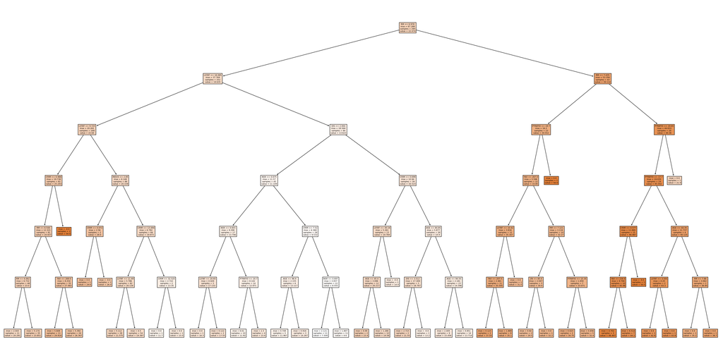

```python
md.fit(X_train, y_train)
plt.figure(figsize=(40,20), dpi=150)
plot_tree(md, filled=True, feature_names=X.columns)
plt.show()
# Se recomienda abrir la imagen en una ventana nueva para poder detallar la información.
```

# Doceavo Punto

*Ahora aplicaremos el método de vecinos más cercanos para regresión. Utilize el KNeighbors regressor de SKLearn para predecir nuestra variable objetivo usando diferentes valores del pará el parámetro k. Quédese con el mejor parámetro y mencione su score.*

```python
scores = []
kss = []
for k in range(1, 101):
    knn = KNeighborsRegressor(n_neighbors=k)
    knn.fit(X_train, y_train)
    scores.append(knn.score(X_test, y_test))
    kss.append(k)
print("Máximo Score:", max(scores), " , ", "parámetro empleado:", scores.index(max(scores)))
```

```
Máximo Score: 0.6401678623169154  ,  parámetro empleado: 2
```

# Treceavo Punto

*Finalmente, compare los resultados obtenidos con los distintos métodos. ¿Cuál tuvo un mejor desempeño? ¿Cuál tuvo un peor desemempeño? Mencione cualquier otra conclusión que extraiga de estos resultados o de los datos, por ejemplo: ¿por qué podría haberse comportado mejor un modelo que otro?*

Basándonos en los resultados obtenidos, podemos concluir que el modelo de árbol de decisión y el modelo de regresión lineal son los que mejor se ajustaron a los datos de precios de casas. Cabe señalar que el modelo basado en KNN podría haberse visto limitado por la alta dimensionalidad del conjunto de datos y por la falta de normalización de los atributos, lo cual puede afectar su capacidad para encontrar patrones significativos en los datos. En contraste con el modelo de regresión Lasso tuvo el peor desempeño, lo cual puede deberse a que la selección de características puede haber eliminado algunas características importantes.

En general, los modelos que utilizan técnicas más sofisticadas, como el árbol de decisión, obtuvieron un mejor desempeño que el modelo el modelo KNN. Sugiriendo que, en este conjunto de datos, la complejidad del modelo es importante para capturar la complejidad subyacente en los datos y mejorar su capacidad para hacer predicciones precisas. Aunque esto entra en conflicto al evidenciar que la regresión lineal fue mejor que Ridge y Lasso. Estos modelos que utilizaron técnicas de regularización, obtuvieron resultados similares, evidenciando que en este conjunto de datos la regularización no tuvo un gran impacto en el rendimiento del modelo.

Finalmente, es importante destacar que cada modelo tiene sus fortalezas y debilidades, y el desempeño de cada uno dependerá de las características específicas del conjunto de datos y del problema en cuestión. En este caso, es posible que el modelo basado en árboles de decisión haya obtenido un mejor desempeño debido a que pudo capturar de manera efectiva las interacciones no lineales entre los atributos, lo cual puede ser difícil de lograr con modelos lineales como Lasso y Ridge. Además, el hecho de que Ridge haya obtenido un desempeño ligeramente mejor que Lasso sugiere que no hay una penalización significativa por mantener todos los atributos en el modelo, lo cual podría ser indicativo de que muchos de los atributos son importantes para predecir el precio de las casas.